# lab3b_2.1

## 0. HairColour vs. Pain

### 0.1 Boxplot

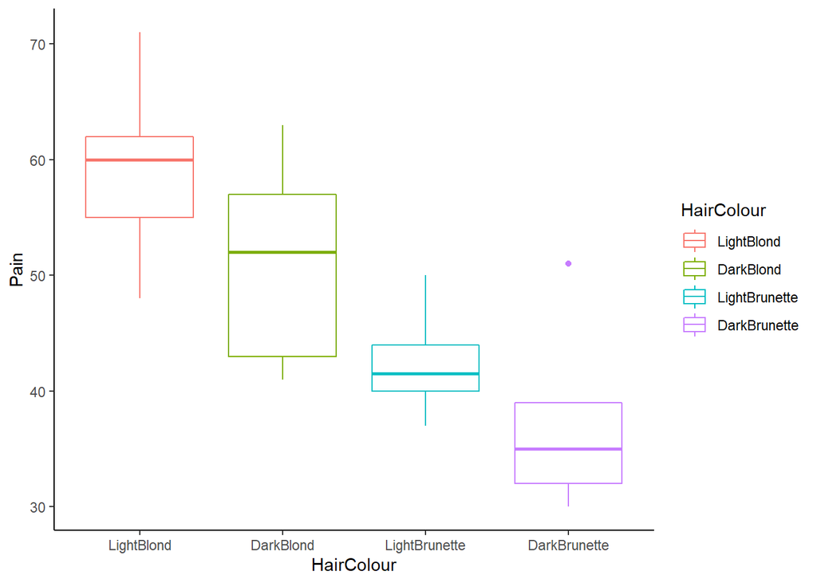

### 0.2 ANOVA

```
##             Df Sum Sq Mean Sq F value  Pr(>F)
## HairColour   3   1361   453.6   6.791 0.00411 **
## Residuals   15   1002    66.8
## ---
## Signif. codes:  0 '***' 0.001 '**' 0.01 '*' 0.05 '.' 0.1 ' ' 1
```

## Question 1.

**Compute the standard error of each pairwise difference (note, there are only two different standard errors over the 4C2=6 pairwise differences).**

The residual standard error is given below

```
## [1] 8.173127
```

These different standard errors come from the difference in number of observations per group. We have 1 group of size 4 and 3 groups of size 5.

```
## # A tibble: 4 x 3
##   HairColour        n  ybar
##   <fct>         <int> <dbl>
## 1 LightBlond        5  59.2
## 2 DarkBlond         5  51.2
## 3 LightBrunette     4  42.5
## 4 DarkBrunette      5  37.4
```

When both sample sizes are 5, the standard error is

```
## [1] 5.169139
```

When one sample is 4 and the other sample is 5, the standard error is

```
## [1] 5.4827
```

## Question 2.

**Compute t-statistics for all 6 pairwise comparisons.**

```
##       [,1]  [,2] [,3] [,4]
## [1,]   0.0   8.0 16.7 21.8
## [2,]  -8.0   0.0  8.7 13.8
## [3,] -16.7  -8.7  0.0  5.1
## [4,] -21.8 -13.8 -5.1  0.0
```

We obtain a matrix of residual standard errors using the outer() function.

```
##          [,1]     [,2]     [,3]     [,4]
## [1,] 5.169139 5.169139 5.482700 5.169139
## [2,] 5.169139 5.169139 5.482700 5.169139
## [3,] 5.482700 5.482700 5.779273 5.482700
## [4,] 5.169139 5.169139 5.482700 5.169139
```

The t-statistics are given by the “ratio” of the difference matrix and the standard error matrix.

```
##           [,1]      [,2]       [,3]      [,4]
## [1,]  0.000000  1.547646  3.0459445 4.2173366
## [2,] -1.547646  0.000000  1.5868094 2.6696902
## [3,] -3.045944 -1.586809  0.0000000 0.9301986
## [4,] -4.217337 -2.669690 -0.9301986 0.0000000
```

## Question 3.

**Using the output below and the Bonferroni method, determine the appropriate multiplier for constructing 6 simultaneous confidence intervals at both the 95% and 99% confidence levels.**

```
##      upper.tail.area t.quantile
## [1,]    0.0500000000   1.753050
## [2,]    0.0250000000   2.131450
## [3,]    0.0083333333   2.693739
## [4,]    0.0041666667   3.036283
## [5,]    0.0100000000   2.602480
## [6,]    0.0050000000   2.946713
## [7,]    0.0016666667   3.483677
## [8,]    0.0008333333   3.821973
```

For 95% intervals

```
## [1] 3.036283
```

For 99% intervals

```
## [1] 3.821973
```

## Question 4.

**Which differences are significant at the 5% level**

In the t-statistics matrix we can see that LightBlond(1)-LightBrunette(3) and LightBlond(1)-DarkBrunette(4) have higher t-statistics than at the 5% level. Therefore, these two interaction groups are significant.

**Which differences are significant at the 1% level**

Only LightBlond(1)-DarkBrunette(4) are significant at the 1% level because it is the only interaction with a larger t-statistics than the 1% level of significance.

## Question 5.

**Check your answers using the emmeans package. Do your conclusions change if you use Tukey’s or Scheffe’s method?**

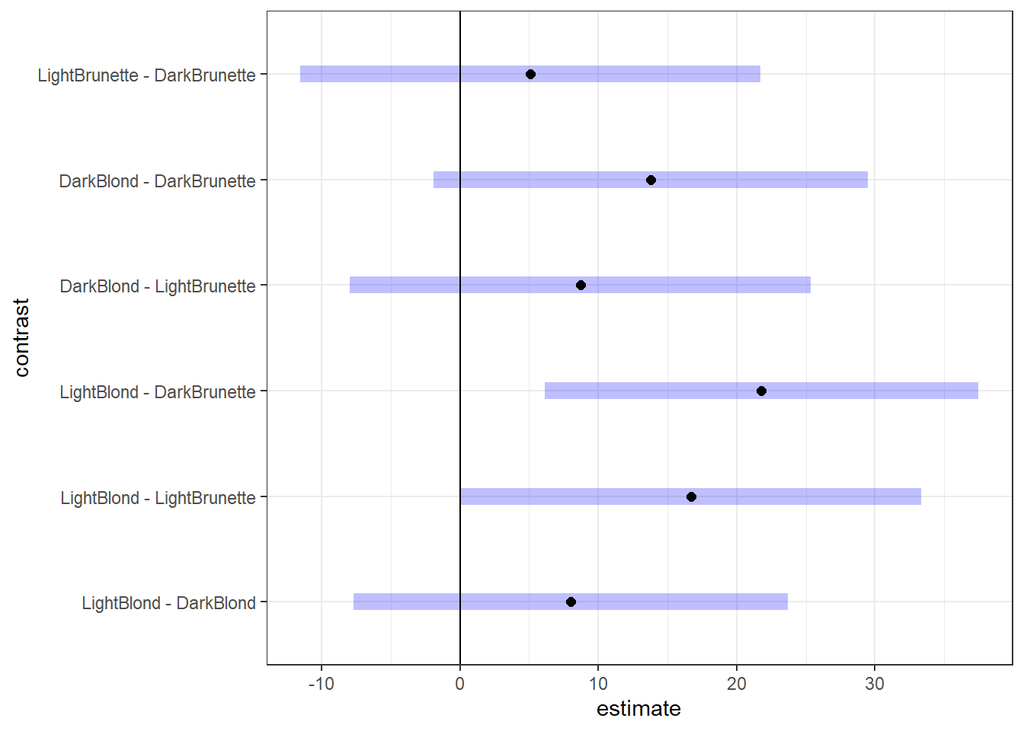